# pulmonic_stenosis_data_simulation

## Summaries of coefficients

### HPDI for the different beta parameters

```r
draws <- as.matrix(mod_clin_si_bias3)
median(draws[,2]) # 2nd column is draws for clinical_signs
```

```
## [1] 0.8416073
```

```r
HPDI(draws[,2], 0.97) # 2nd column is draws for clinical_signs
```

```
##     |0.97     0.97|
## 0.2301961 1.4680170
```

```r
HPDI(draws[,2], 0.89) # 2nd column is draws for clinical_signs
```

```
##     |0.89     0.89|
## 0.3949171 1.3026504
```

### Hypothesis tests on beta parameters

#### clinical_signs

probability that effect is positive

```r
mean(draws[,2] > 0) # 2nd column is draws for clinical_signs
```

```
## [1] 0.999
```

### a. Get HDI for coefficients

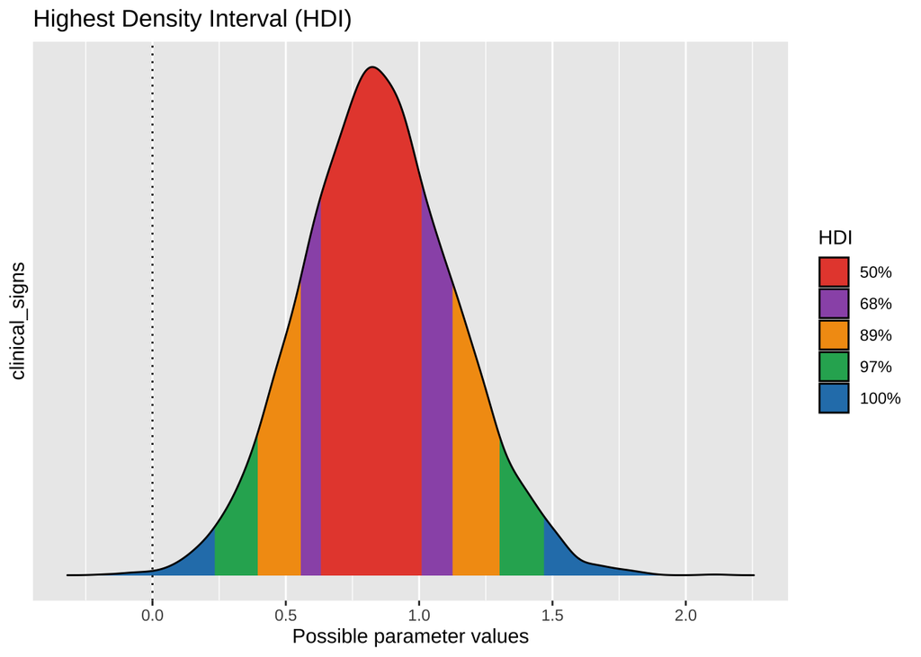

```r
hdi <- bayestestR::hdi(mod_clin_si_bias3, ci = c(0.50, 0.68, 0.89, 0.97), parameters = "clinical_signs")
plot(hdi)
```

## Get density plots for posterior distributons of beta parameters

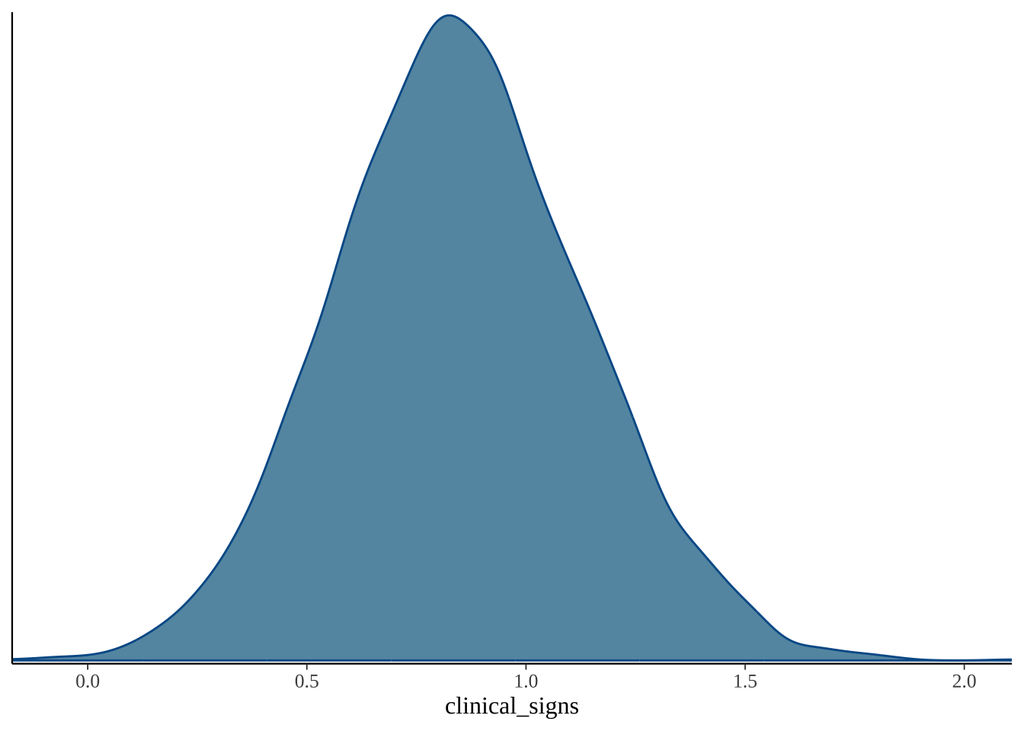

```r
mcmc_dens(posterior_mod_clin_si_bias3,
  pars = c("clinical_signs"))
```

## Get area plot for posterior distributons of beta parameters

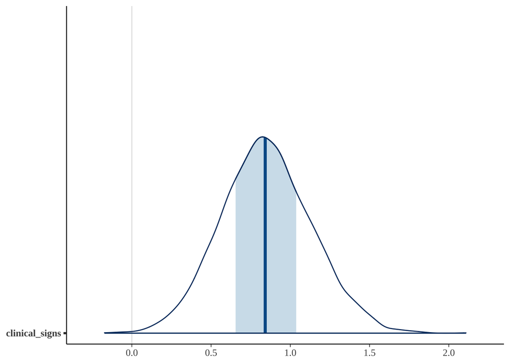

```r
mcmc_areas(posterior_mod_clin_si_bias3,
  pars = "clinical_signs")
```

## Calculate hazard ratios for clinical_signs

### a. get posterior draws

```r
clinical_signs_hr3 <- exp(draws[,2]) # 2nd column is draws for clinical_signs)
```

### b. Summarise hazard ratios for clinical_signs

```r
median(clinical_signs_hr3)
```

```
## [1] 2.320093
```

```r
hdi_clinical_signs_hr3 <- hdi(clinical_signs_hr3, ci = c(0.97))
hdi_clinical_signs_hr3
```

```
##          [,1]    [,2]
## [1,] 1.248114 3.94209
```

### c. Plot posterior distribution for hazard ratio of clinical_signs

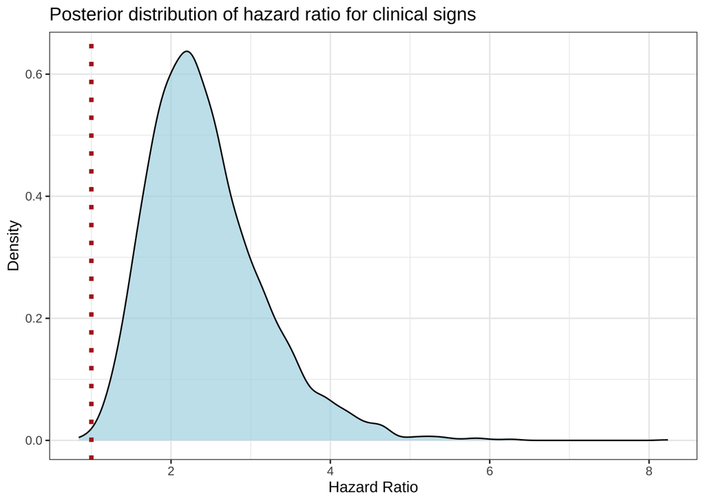

```r
ggplot(data.frame(clinical_signs_hr3), aes(x = clinical_signs_hr3)) +
  geom_density(fill = "lightblue", alpha = 0.7) +
  labs(title = "Posterior distribution of hazard ratio for clinical signs",
       x = "Hazard Ratio",
       y = "Density") +
  theme_bw() +
  geom_vline(xintercept = 1, linetype="dotted",
                color = "firebrick", linewidth = 1.5)
```

## Check model performance

### check performance of posterior probability

NB equivalent of pp_check

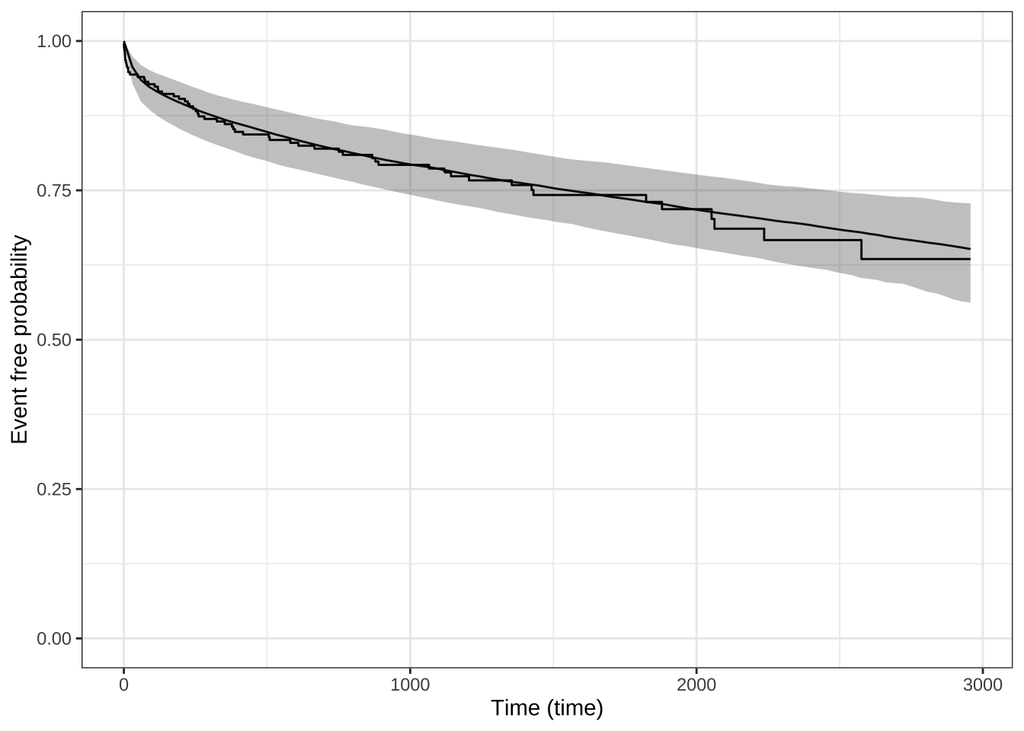

```r
ps_check(mod_clin_si_bias3) |>
  suppressWarnings()
```

### check performance of prior probability

```r
mod_final_prior_only <- update(mod_clin_si_bias3, prior_PD = TRUE)
```

[output not shown]

[output not shown]

[output not shown]

[output not shown]

[output not shown]

[output not shown]

[output not shown]

[output not shown]

[output not shown]

[output not shown]

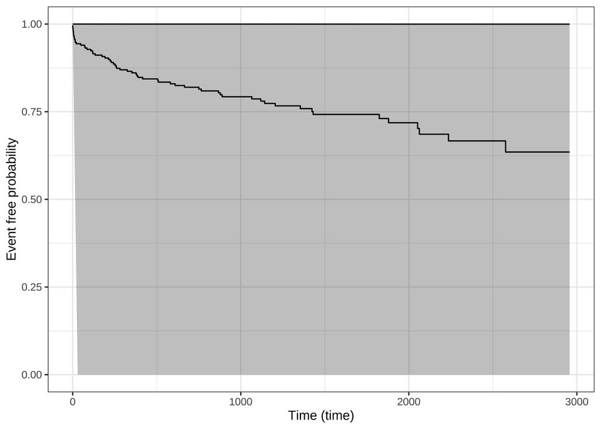

```r
ps_check(mod_final_prior_only) |>
  suppressWarnings()
```

## Make model predictions and plot for clinical_signs

### create new data where clinical_signs differs

```r
nd <- data.frame(centre = rep("A", 2),
                 clinical_signs = c(0, 1)
                 )
head(nd)
```

```
##   centre clinical_signs
## 1      A              0
## 2      A              1
```

### make posterior predictions from new data

```r
ps <- posterior_survfit(mod_clin_si_bias3,
  newdata = nd,
  times = 0,
  extrapolate = TRUE) |>
  suppressWarnings()
head(ps)
```

```
## stan_surv predictions
##  num. individuals: 2
##  prediction type:  event free probability
##  standardised?:    no
##  conditional?:     no
##
##   id cond_time     time median  ci_lb  ci_ub
## 1  1        NA   0.0000 1.0000 1.0000 1.0000
## 2  1        NA  29.8679 0.9758 0.9544 0.9883
## 3  1        NA  59.7358 0.9635 0.9357 0.9819
## 4  1        NA  89.6037 0.9573 0.9269 0.9779
## 5  1        NA 119.4716 0.9525 0.9192 0.9765
## 6  1        NA 149.3395 0.9481 0.9117 0.9745
```

### plot

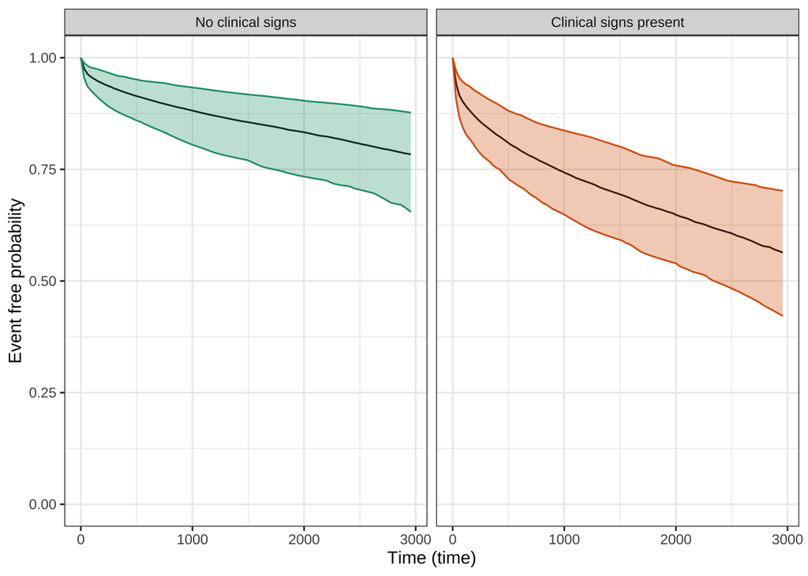

```r
panel_labels <- c('1' = "No clinical signs", '2' = "Clinical signs present")
pps <- plot(ps) +
  aes(colour = factor(id), fill = factor(id)) +
  scale_colour_brewer(palette = "Dark2") +
  scale_fill_brewer(palette = "Dark2") +
  theme(legend.position = "none") +
  facet_wrap(~ id, labeller = labeller(id = panel_labels))
print(pps)
```

## Check PH assumption visually

### make predictions of both the hazard and log hazard

```r
ph <- suppressWarnings(posterior_survfit(mod_clin_si_bias3, newdata = nd, type = "haz"))
pl <- suppressWarnings(posterior_survfit(mod_clin_si_bias3, newdata = nd, type = "loghaz"))
```

#### create plots

```r
pph <- plot(ph) +
  coord_cartesian(ylim = c(0.0, 0.005)) +
  facet_wrap(~ id, labeller = labeller(id = panel_labels))
```

```
## ℹ Adding new coordinate system, which will replace the existing one.
```

```r
ppl <- plot(pl) +
  facet_wrap(~ id, labeller = labeller(id = panel_labels))
```

#### combine plots in grid and plot

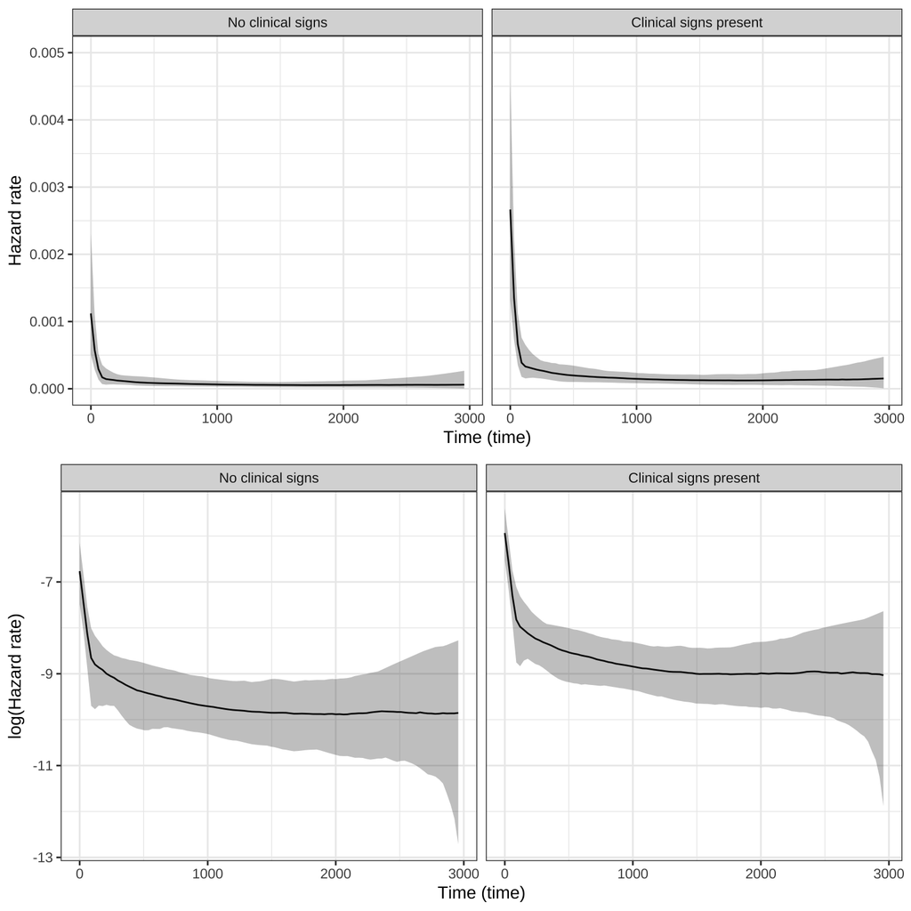

```r
plot_grid(pph, ppl, ncol = 1)
```

## Create KM curve for right clinical_signs

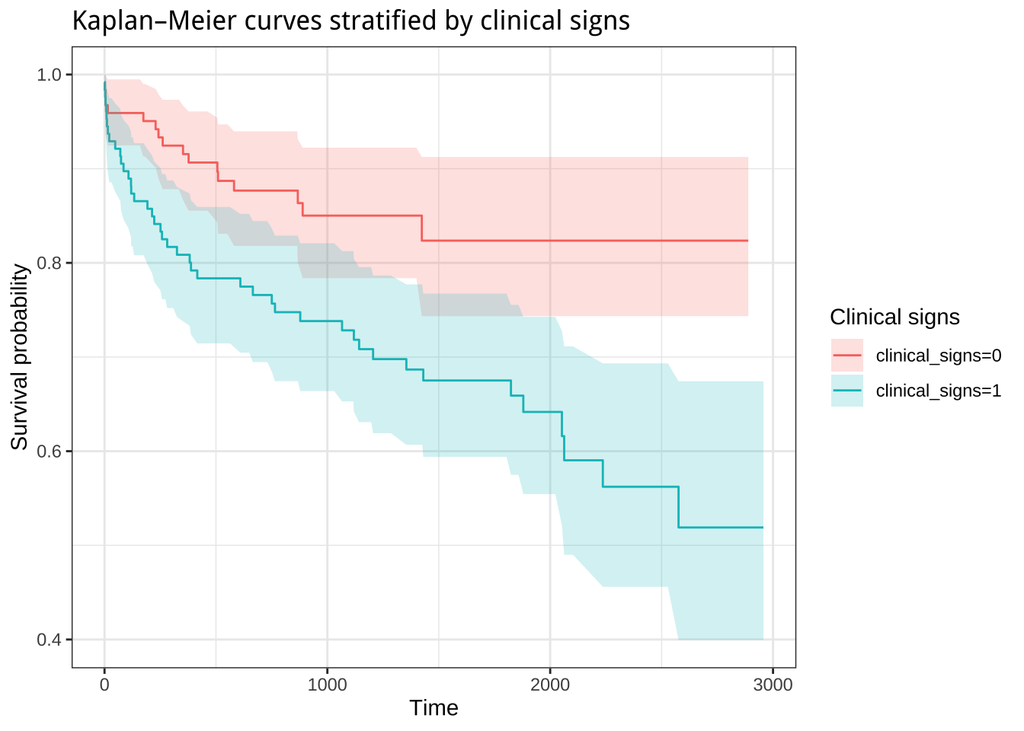

```r
# Basic KM curve for the entire dataset
km_strat <- survfit(Surv(time, status) ~ 1 + clinical_signs, data = sim_data3)

# Convert to tidy format
km_df <- broom::tidy(km_strat)


# Columns: time, estimate, conf.low, conf.high, strata, n.risk, n.event, n.censor
ggplot(km_df, aes(x = time, y = estimate, colour = strata, fill = strata)) +
  geom_step() +
  geom_ribbon(aes(ymin = conf.low, ymax = conf.high), alpha = 0.2, colour = NA) +
  theme_bw() +
  labs(
    x = "Time",
    y = "Survival probability",
    colour = "Clinical signs",
    fill = "Clinical signs",
    title = "Kaplan–Meier curves stratified by clinical signs"
  )
```

## Fit frequentist Cox PH model for effect of right clinical_signs

```r
# Fit Cox PH model
freq_cox_clinical_signs3 <- coxph(Surv(time, status) ~ 1 + clinical_signs + strata(centre),
                data = sim_data3)

summary(freq_cox_clinical_signs3)
```

```
## Call:
## coxph(formula = Surv(time, status) ~ 1 + clinical_signs + strata(centre),
##     data = sim_data3)
##
##   n= 250, number of events= 61
##
##                  coef exp(coef) se(coef)     z Pr(>|z|)
## clinical_signs 0.8260    2.2841   0.2876 2.872  0.00408 **
## ---
## Signif. codes:  0 '***' 0.001 '**' 0.01 '*' 0.05 '.' 0.1 ' ' 1
##
##                exp(coef) exp(-coef) lower .95 upper .95
## clinical_signs     2.284     0.4378       1.3     4.014
##
## Concordance= 0.586  (se = 0.034 )
## Likelihood ratio test= 9.08  on 1 df,   p=0.003
## Wald test            = 8.25  on 1 df,   p=0.004
## Score (logrank) test = 8.71  on 1 df,   p=0.003
```

# III. Bayesian Cox’s regression for TRUE effect of CLINICAL SIGNS with random intercept for centre

# AND also for the DIRECT EFFECT of CHF

## Non-informative prior for clinical_signs

```r
prior_clin_si_chf <- student_t(df = 3,
                           location = 0,
                           scale = 2,
                           autoscale = FALSE)
```

## Fit model

NB use status … rstanarm requires the dead animals to be classified as 1, whilst censored are 0.

```r
mod_clin_si_true3 <- stan_surv(formula = Surv(time, status) ~ 1 + clinical_signs + chf + (1| centre),
  data = sim_data3,
  basehaz = "ms",
  prior = prior_clin_si_chf,
  prior_intercept = normal(location = 0, scale = 10, autoscale = FALSE),
  prior_covariance =  decov(regularization = 2, concentration = 1, shape = 1, scale = 1),
  iter    = 2000,
  chains = 4,
  cores = 4,
  adapt_delta = 0.999,  # Often helpful for complex models
  seed = 666)
```

[output not shown]

[output not shown]

[output not shown]

[output not shown]

[output not shown]

[output not shown]

[output not shown]

[output not shown]

[output not shown]

[output not shown]

## Summarise priors from model

```r
prior_summary(mod_clin_si_true3)
```

```
## Priors for model 'mod_clin_si_true3'
## ------
## Intercept
##  ~ normal(location = 0, scale = 10)
##
## Coefficients
##  ~ student_t(df = [3,3], location = [0,0], scale = [2,2])
##
## Auxiliary (M-spline-coefficients)
##  ~ dirichlet(concentration = [1,1,1,...])
##
## Covariance
##  ~ decov(reg. = 2, conc. = 1, shape = 1, scale = 1)
## ------
## See help('prior_summary.stanreg') for more details
```

## Model summary

```r
summary(mod_clin_si_true3)
```

[output not shown]

NOTE estimates for clinical signs and chf are now correct (~0.5) based on what was included in the synthetic dataset

## Model short summary

```r
print(mod_clin_si_true3, digits = 3)
```

```
## stan_surv
##  baseline hazard: M-splines on hazard scale
##  formula:         Surv(time, status) ~ 1 + clinical_signs + chf + (1 | centre)
##  observations:    250
##  events:          61 (24.4%)
##  right censored:  189 (75.6%)
##  delayed entry:   no
## ------
##                 Median MAD_SD exp(Median)
## (Intercept)     -1.658  0.386     NA
## clinical_signs   0.638  0.311  1.892
## chf              0.574  0.332  1.776
## m-splines-coef1  0.151  0.042     NA
## m-splines-coef2  0.113  0.053     NA
## m-splines-coef3  0.328  0.098     NA
## m-splines-coef4  0.083  0.075     NA
## m-splines-coef5  0.128  0.106     NA
## m-splines-coef6  0.143  0.111     NA
##
## Error terms:
##  Groups Name        Std.Dev.
##  centre (Intercept) 0.5123
## Num. levels: centre 3
##
## ------
## * For help interpreting the printed output see ?print.stanreg
## * For info on the priors used see ?prior_summary.stanreg
```

## Plot Baseline hazard of model

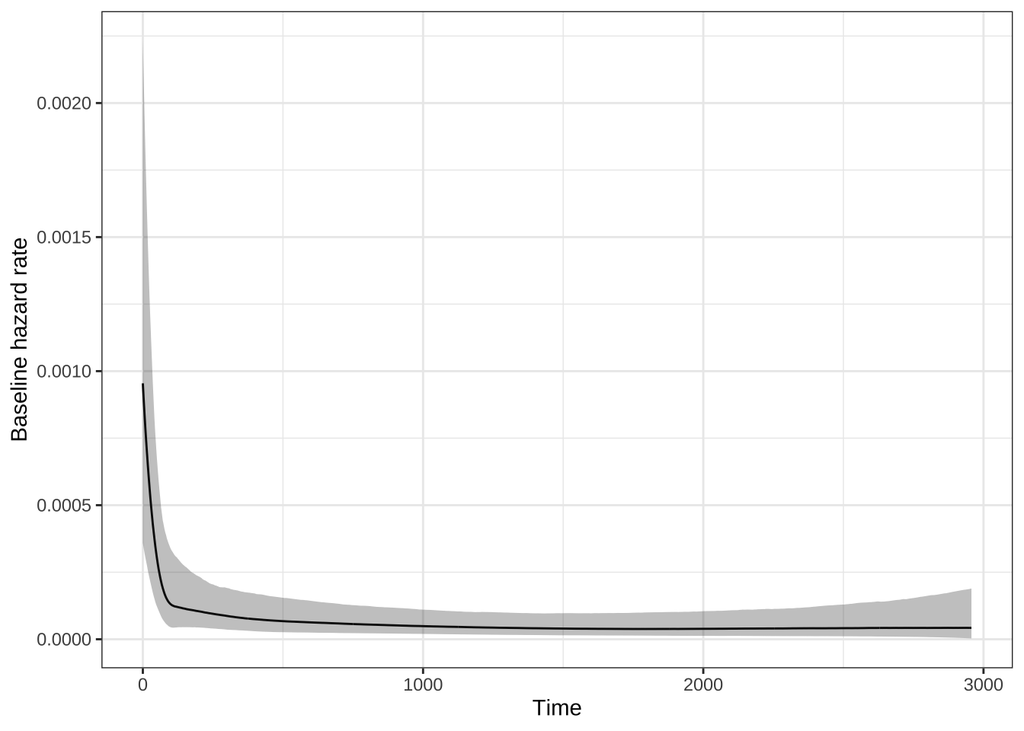

```r
plot(mod_clin_si_true3)
```

## Plots of model convergences

## Get results

```r
posterior_mod_clin_si_true3 <- as.array(mod_clin_si_true3)
```

### a. Check trace plots for model

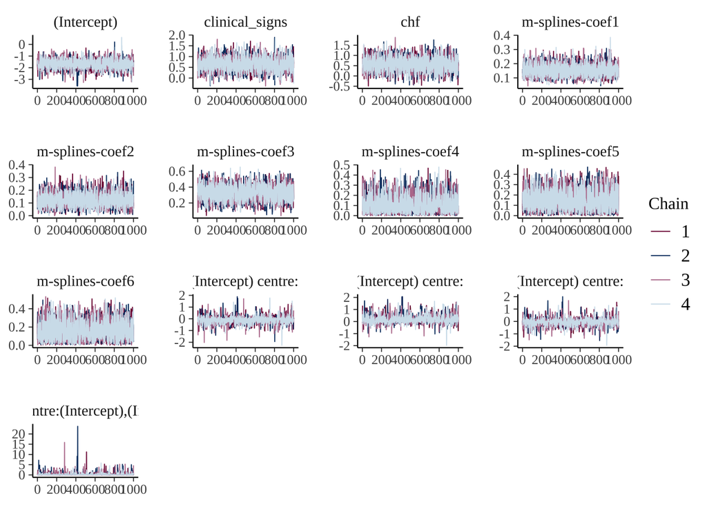

```r
color_scheme_set("mix-blue-pink")
mcmc_trace(posterior_mod_clin_si_true3)
```

### b. Trace rank plot

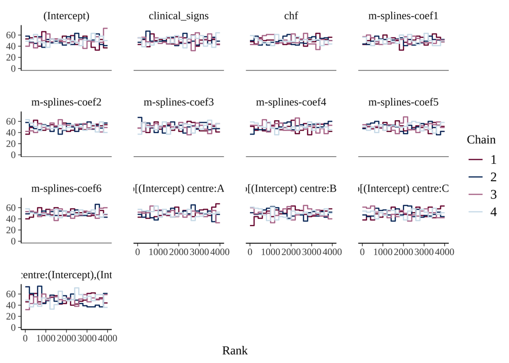

```r
mcmc_rank_overlay(posterior_mod_clin_si_true3)
```

### c. get dens overlay plot for chains

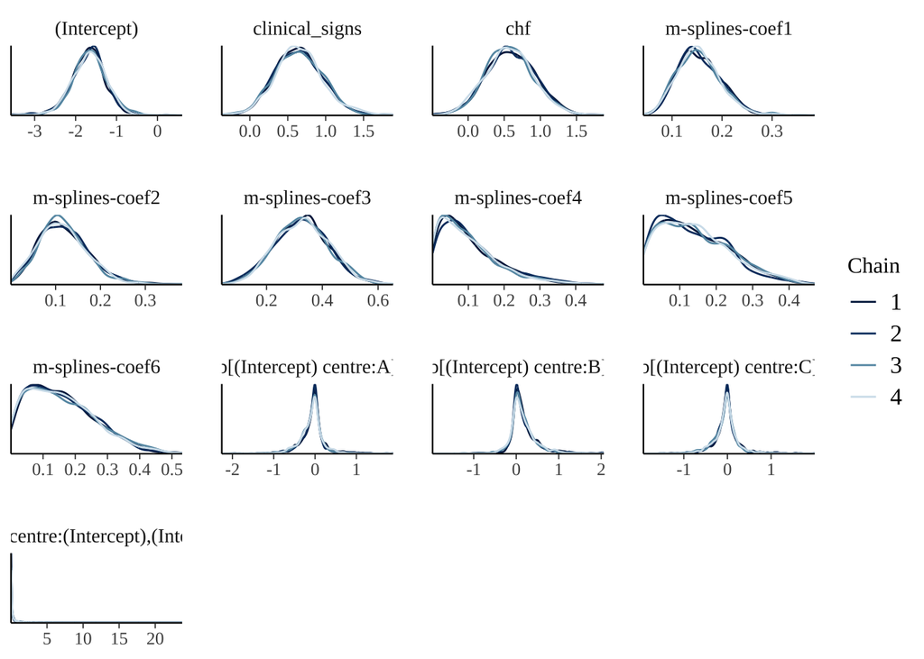

```r
color_scheme_set("blue")
mcmc_dens_overlay(posterior_mod_clin_si_true3)
```

## Summaries of coefficients

### HPDI for the different beta parameters

#### clinical signs

```r
draws <- as.matrix(mod_clin_si_true3)
median(draws[,2]) # 2nd column is draws for clinical_signs
```

```
## [1] 0.6376553
```

```r
HPDI(draws[,2], 0.97) # 2nd column is draws for clinical_signs
```

```
##       |0.97       0.97|
## -0.02685346  1.32127901
```

```r
HPDI(draws[,2], 0.89) # 2nd column is draws for clinical_signs
```

```
##     |0.89     0.89|
## 0.1410477 1.1103664
```

#### chf

```r
draws <- as.matrix(mod_clin_si_true3)
median(draws[,3]) # 2nd column is draws for chf
```

```
## [1] 0.5743252
```

```r
HPDI(draws[,3], 0.97)
```

```
##      |0.97      0.97|
## -0.1025242  1.3252426
```

```r
HPDI(draws[,3], 0.89)
```

```
##      |0.89      0.89|
## 0.05247457 1.11432765
```

### Hypothesis tests on beta parameters

#### clinical_signs

probability that effect is positive

```r
mean(draws[,2] > 0) # 2nd column is draws for clinical_signs
```

```
## [1] 0.986
```

#### chf

probability that effect is positive

```r
mean(draws[,3] > 0) # 2nd column is draws for chf
```

```
## [1] 0.96275
```

### a. Get HDI for coefficients

#### i. clinical signs

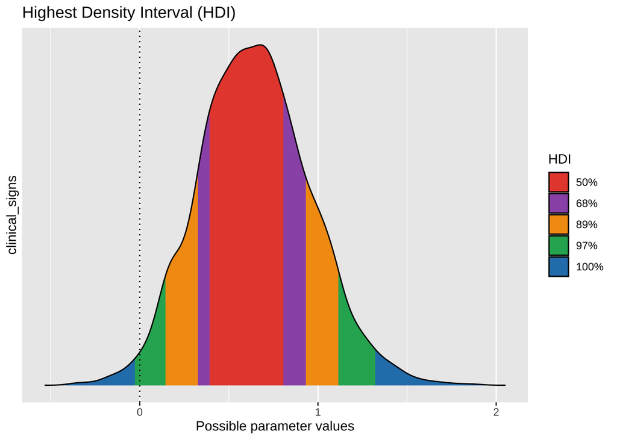

```r
hdi <- bayestestR::hdi(mod_clin_si_true3, ci = c(0.50, 0.68, 0.89, 0.97), parameters = "clinical_signs")
plot(hdi)
```

#### ii. chf

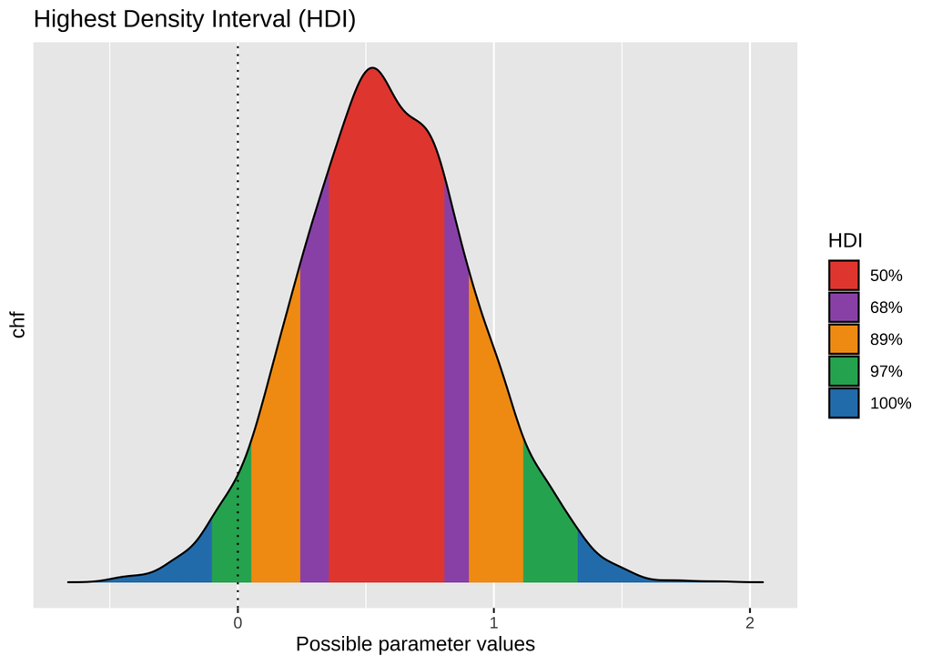

```r
hdi <- bayestestR::hdi(mod_clin_si_true3, ci = c(0.50, 0.68, 0.89, 0.97), parameters = "chf")
plot(hdi)
```

## Calculate hazard ratios for clinical_signs

### a. get posterior draws

```r
clinical_signs_hr3 <- exp(draws[,2]) # 2nd column is draws for clinical_signs)
```

### b. Summarise hazard ratios for clinical_signs

```r
median(clinical_signs_hr3)
```

```
## [1] 1.892039
```

```r
hdi_clinical_signs_hr3 <- hdi(clinical_signs_hr3, ci = c(0.97))
hdi_clinical_signs_hr3
```

```
##           [,1]     [,2]
## [1,] 0.9450295 3.324399
```

### c. Plot posterior distribution for hazard ratio of clinical_signs

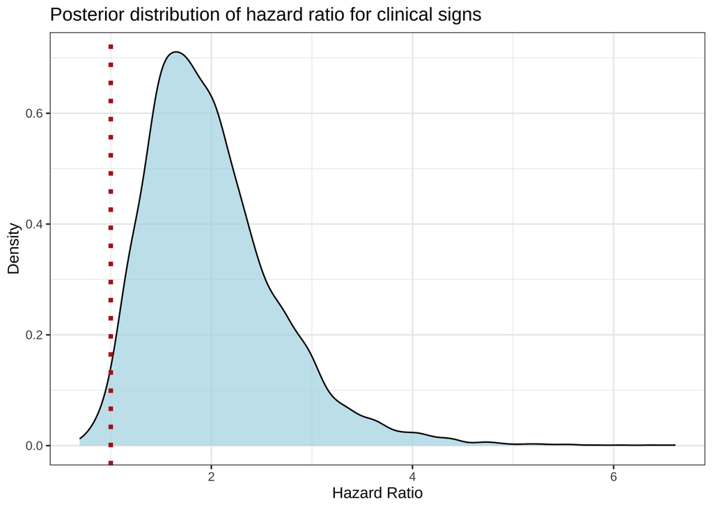

```r
ggplot(data.frame(clinical_signs_hr3), aes(x = clinical_signs_hr3)) +
  geom_density(fill = "lightblue", alpha = 0.7) +
  labs(title = "Posterior distribution of hazard ratio for clinical signs",
       x = "Hazard Ratio",
       y = "Density") +
  theme_bw() +
  geom_vline(xintercept = 1, linetype="dotted",
                color = "firebrick", linewidth = 1.5)
```

## Calculate hazard ratios for chf

### a. get posterior draws

```r
chf_hr3 <- exp(draws[,3]) # 2nd column is draws for chf
```

### b. Summarise hazard ratios for chf

```r
median(chf_hr3)
```

```
## [1] 1.775932
```

```r
hdi_chf_hr3 <- hdi(chf_hr3, ci = c(0.97))
hdi_chf_hr3
```

```
##           [,1]     [,2]
## [1,] 0.8377285 3.279251
```

### c. Plot posterior distribution for hazard ratio of chf

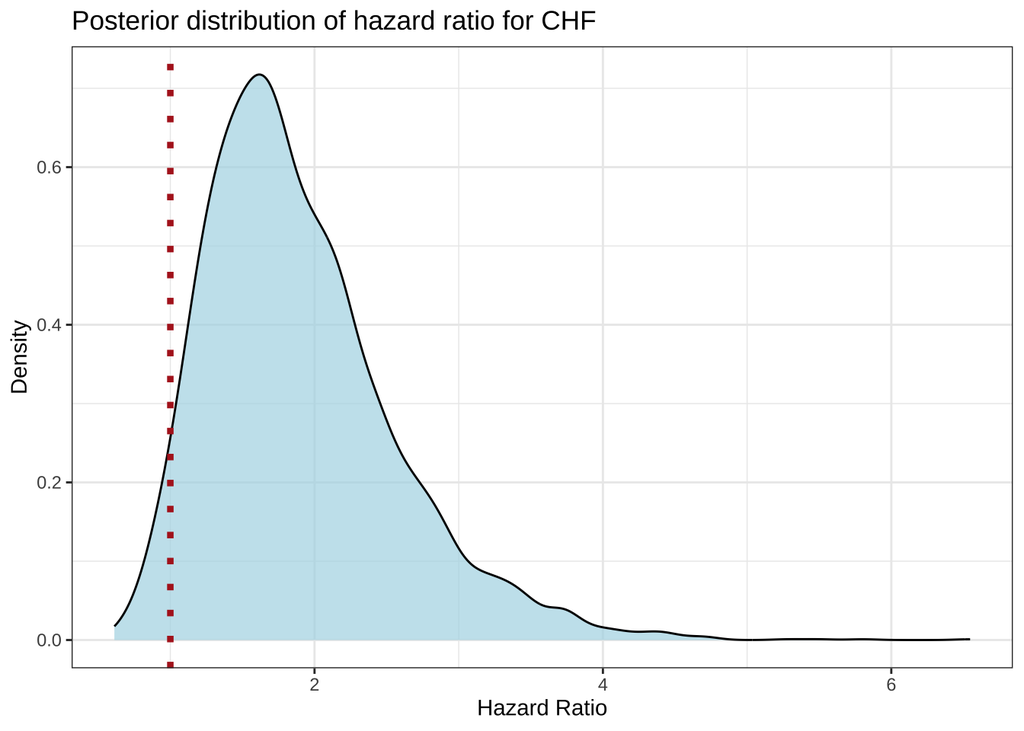

```r
ggplot(data.frame(chf_hr3), aes(x = chf_hr3)) +
  geom_density(fill = "lightblue", alpha = 0.7) +
  labs(title = "Posterior distribution of hazard ratio for CHF",
       x = "Hazard Ratio",
       y = "Density") +
  theme_bw() +
  geom_vline(xintercept = 1, linetype="dotted",
                color = "firebrick", linewidth = 1.5)
```

## Check model performance

### check performance of posterior probability

NB equivalent of pp_check

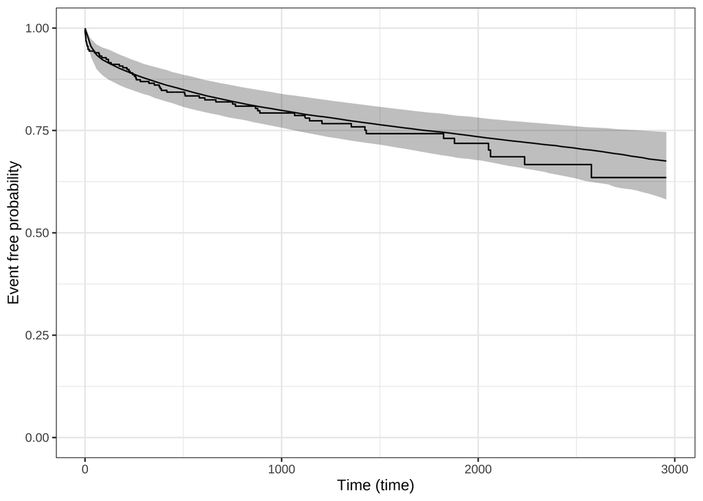

```r
ps_check(mod_clin_si_true3) |>
  suppressWarnings()
```

### check performance of prior probability

```r
mod_final_prior_only <- update(mod_clin_si_true3, prior_PD = TRUE)
```

[output not shown]

[output not shown]

[output not shown]

[output not shown]

[output not shown]

[output not shown]

[output not shown]

[output not shown]

[output not shown]

[output not shown]

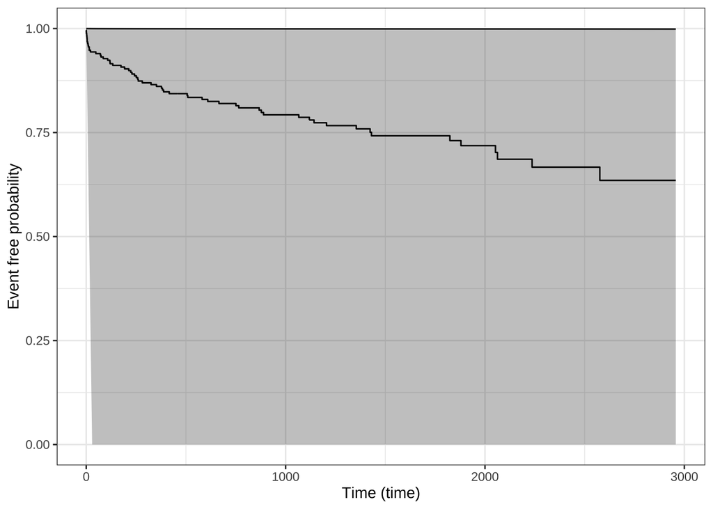

```r
ps_check(mod_final_prior_only) |>
  suppressWarnings()
```